# R Crash Course Part 1 – Fundamentals TEST

Rob Colautti

# Test your understanding of R Fundamentals

Learning R takes patience and practice.

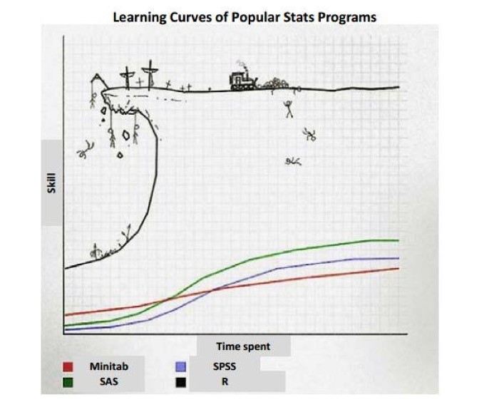

Practice writing code for the examples below. Then reveal the code and compare to what you have written. It’s okay if your code does not match exactly – there is often more than one way to get to an answer!

# 2. R Basics

Make comments inside your code. Very important (unless you are using R markdown or R notebooks)!

```r
# Use hastags to make comments - not read by the R console
# Use other characters and blank lines to improve readability:
# -------------------------
# My first R script
# Today's Date
# -------------------------
# Add a summary description of what the script does
# This script will...
# And annotate individual parts of the script
```

## Basic Math

add, subtract, multiply, divide, exponent

```r
10+2 # add
10-2 # subtract
10*2 # multiply
10/2 # divide
10^2 # exponent
```

absolute value, square root, natural log (ln), log base 10, e to the power of 6

```r
abs(-10) # absolute value
sqrt(10-1) # square root (with subtraction)
log(10) # natural log
log10(10) # log base 10
exp(6) # power of e
```

sine, cosine, tangent and their inverse

```r
sin(pi/2) # sine function
asin(1) # inverse sine
cos(pi) # cosine
acos(-1) # inverse cosine
tan(0) # tangent
atan(0) # inverse tangent
```

## Round/Truncate

round to 3 decimal places; round down; round up; keep 2 significant digits

```r
round(pi,digits=3) # standard rounding to 3 digits
floor(pi) # round down to closest whole number
ceiling(pi) # round up to closest whole number
signif(pi,digits=2) # round to keep 2 significant digits
```

## Logic Operators

greater, less, equal, not equal, ‘OR’ ‘AND’

```r
1 > 2 # greater than
1 < 2 # less than
1 <= 2 # less than or equal to
1 == 1 # equal to
1 != 1 # not equal to
1 == 2 | 1 # | means 'OR'
1 == 2 & 1 # & means 'AND'
```

what can you use instead of `|` to check for a value in a large number of items/objects?

```r
6 %in% c(1,2,3,4,5,6,7,8,9,10)
```

## Random Number Generators

Generate 10 numbers from each of the following:

Uniform distribution

```r
runif(10,min=0,max=1)
```

```
##  [1] 0.495529568 0.633343884 0.960522431 0.003800493 0.391253901
##  [6] 0.106122630 0.200390417 0.460215609 0.350966865 0.243174366
```

```r
rnorm(10,mean=0,sd=1)
```

```
##  [1]  1.85930059 -0.98977985  0.83615181 -1.51384345 -0.32006504
##  [6]  0.69983535  0.07408616  0.30143572  0.21371264  1.15386225
```

```r
rpois(10,lambda=10)
```

```
##  [1] 10 10 14  6  5  8  7 15 13 14
```

Bernoulli variable (Binomial distribution) to model a coin toss (one coin, 10 separate trials)

```r
rbinom(10,size=1,prob=0.5)
```

```
##  [1] 0 0 1 1 1 1 1 1 0 0
```

Bernoulli variable (Binomial distribution) to model the number of Adenine nucleotides found in a stretch of 100bp of DNA (assuming equal representation of the 4 base pairs) – repeated for 10 independent strands of DNA

```r
rbinom(10,size=100,prob=0.25)
```

```
##  [1] 24 27 17 18 22 31 26 19 29 27
```

## Combining objects

Make a vector of 3 letters

```r
c('a','b','c')
```

```
## [1] "a" "b" "c"
```

Make a vector of numbers 1 to 100

```r
c(1:100)
```

```
##   [1]   1   2   3   4   5   6   7   8   9  10  11  12  13  14  15  16  17
##  [18]  18  19  20  21  22  23  24  25  26  27  28  29  30  31  32  33  34
##  [35]  35  36  37  38  39  40  41  42  43  44  45  46  47  48  49  50  51
##  [52]  52  53  54  55  56  57  58  59  60  61  62  63  64  65  66  67  68
##  [69]  69  70  71  72  73  74  75  76  77  78  79  80  81  82  83  84  85
##  [86]  86  87  88  89  90  91  92  93  94  95  96  97  98  99 100
```

Make a vector of numbers counting from 1.1 to 10.1 by 0.1

```r
c(11:101)/10
```

```
##  [1]  1.1  1.2  1.3  1.4  1.5  1.6  1.7  1.8  1.9  2.0  2.1  2.2  2.3  2.4
## [15]  2.5  2.6  2.7  2.8  2.9  3.0  3.1  3.2  3.3  3.4  3.5  3.6  3.7  3.8
## [29]  3.9  4.0  4.1  4.2  4.3  4.4  4.5  4.6  4.7  4.8  4.9  5.0  5.1  5.2
## [43]  5.3  5.4  5.5  5.6  5.7  5.8  5.9  6.0  6.1  6.2  6.3  6.4  6.5  6.6
## [57]  6.7  6.8  6.9  7.0  7.1  7.2  7.3  7.4  7.5  7.6  7.7  7.8  7.9  8.0
## [71]  8.1  8.2  8.3  8.4  8.5  8.6  8.7  8.8  8.9  9.0  9.1  9.2  9.3  9.4
## [85]  9.5  9.6  9.7  9.8  9.9 10.0 10.1
```

# 3. Defining variables / objects

## Cells

Define an object $X$ as the word $string$

```r
X<-"string"
```

A few options To see the contents of **X**:

```r
# Any of these will work:
print(X)
paste(X)
X
```

#### What’s the difference?

What is the difference between `X`, `print(X)` and `paste(X)`?

```r
# print() Is most generic, useful for providing feedback from running scripts (e.g. during loops, Bash scripts, etc)

# paste() Converts objects to a string, we'll come back to this.

# Generally print() or paste() are preferred over calling the object directly.
```

### Subsetting objects

```r
Xvec<-c(1:36)*0.1
```

Print the 1st, 3rd and 9th elements of `Xvec` as a single string

```r
Xvec[c(1,3,9)]
```

```
## [1] 0.1 0.3 0.9
```

## Matrices

Make a matrix called `Xmat` by converting the 1x36 `Xvec` vector to a 6x6 matrix

```r
Xmat<-matrix(Xvec,nrow=6)
```

### Subset a matrix

Print the number from the 1st row, 3rd column of the matrix object `Xmat`

```r
Xmat[1,3]
```

```
## [1] 1.3
```

## Higher-order arrays

Make an object containing 2 3x3 matrices (i.e. 3-dimensional array)

```r
Xarray<-array(0, dim=c(3,3,2)) # 3 dimensions
Xarray
```

```
## , , 1
##
##      [,1] [,2] [,3]
## [1,]    0    0    0
## [2,]    0    0    0
## [3,]    0    0    0
##
## , , 2
##
##      [,1] [,2] [,3]
## [1,]    0    0    0
## [2,]    0    0    0
## [3,]    0    0    0
```

### Matrix Algebra Basics

Start with a couple of vectors

```r
X<-c(1:10)
Y<-c(10:1)
```

Multiply each element of the vector X by its corresponding element in vector Y i.e. `X[1]` x `Y[1]`, `X[2]` x `Y[2]`, etc.

```r
X*Y
```

```
##  [1] 10 18 24 28 30 30 28 24 18 10
```

Take every element of Y and raise it to the exponent $e^Y$

```r
exp(Y)
```

```
##  [1] 22026.465795  8103.083928  2980.957987  1096.633158   403.428793
##  [6]   148.413159    54.598150    20.085537     7.389056     2.718282
```

```r
## Remember: you can use pretty much any standard operator for element-by element calculations
```

## More advanced matrix algebra

Standard (‘proper’) matrix multiplication of vector `X` by vector `Y`.

i.e. `X[1]*Y[1]+X[2]*Y[2]`

What will the output be?

```r
X%*%Y
```

```
##      [,1]
## [1,]  220
```

Outer product of `X` and `Y`.

What will the output be?

```r
Z<-X%o%Y
Z
```

```
##       [,1] [,2] [,3] [,4] [,5] [,6] [,7] [,8] [,9] [,10]
##  [1,]   10    9    8    7    6    5    4    3    2     1
##  [2,]   20   18   16   14   12   10    8    6    4     2
##  [3,]   30   27   24   21   18   15   12    9    6     3
##  [4,]   40   36   32   28   24   20   16   12    8     4
##  [5,]   50   45   40   35   30   25   20   15   10     5
##  [6,]   60   54   48   42   36   30   24   18   12     6
##  [7,]   70   63   56   49   42   35   28   21   14     7
##  [8,]   80   72   64   56   48   40   32   24   16     8
##  [9,]   90   81   72   63   54   45   36   27   18     9
## [10,]  100   90   80   70   60   50   40   30   20    10
```

### Principal components analysis

Do a principal components analysis of the matrix `Z` from the previous step

```r
prcomp(Z) # or princomp(Z)
```

```
## Standard deviations (1, .., p=10):
##  [1] 5.940679e+01 7.606314e-15 1.531454e-15 3.472362e-16 1.710185e-16
##  [6] 1.284710e-31 2.560499e-32 2.882308e-33 2.007453e-49 0.000000e+00
##
## Rotation (n x k) = (10 x 10):
##              PC1         PC2         PC3         PC4         PC5
##  [1,] 0.50964719  0.23882156  0.67146336  0.38018862  0.26116992
##  [2,] 0.45868247  0.72317260 -0.47326099 -0.20116553 -0.04677869
##  [3,] 0.40771775 -0.25747535  0.11845612 -0.11119056 -0.70286461
##  [4,] 0.35675303 -0.27863443  0.05111334 -0.39693730  0.38042378
##  [5,] 0.30578831 -0.34382115 -0.48743702  0.57779193  0.12977733
##  [6,] 0.25482360 -0.32639875 -0.08317933 -0.47297502  0.32818980
##  [7,] 0.20385888 -0.12873768  0.05922806 -0.05559528 -0.35143230
##  [8,] 0.15289416 -0.17191058 -0.24371851  0.28889597  0.06488866
##  [9,] 0.10192944 -0.06436884  0.02961403 -0.02779764 -0.17571615
## [10,] 0.05096472 -0.03218442  0.01480701 -0.01389882 -0.08785808
##                 PC6           PC7           PC8           PC9       PC10
##  [1,] -1.237897e-01 -6.498590e-02 -7.796876e-03  0.000000e+00  0.0000000
##  [2,]  6.938894e-17 -1.179612e-16 -5.637851e-17  2.127623e-17  0.0000000
##  [3,]  2.323279e-01 -4.365978e-01 -4.964749e-02 -7.963629e-17  0.0000000
##  [4,]  6.189484e-01  3.249295e-01  3.898438e-02 -1.427361e-17  0.0000000
##  [5,]  1.141871e-03  5.112867e-02 -4.442798e-01 -2.019166e-16  0.0000000
##  [6,] -6.189484e-01 -3.249295e-01 -3.898438e-02 -2.435014e-18  0.0000000
##  [7,] -3.540235e-01  6.652920e-01  7.565332e-02 -4.879500e-01  0.0000000
##  [8,] -2.283742e-03 -1.022573e-01  8.885596e-01  4.020105e-16  0.0000000
##  [9,] -1.770118e-01  3.326460e-01  3.782666e-02  7.807201e-01 -0.4472136
## [10,] -8.850588e-02  1.663230e-01  1.891333e-02  3.903600e-01  0.8944272
```

## Lists

Make a list called *MyList* containing the following elements:

1. A string called *name* that contains your name
2. A vector called *Xvec* that all the elements of the vector X, defined in section 3
3. A vector called *numbers* that contains 10 random numbers

What will the output look like?

```r
MyList<-list(name="Rob",Xvec=X,numbers=runif(10)) # if your name is 'Rob'
MyList
```

```
## $name
## [1] "Rob"
##
## $Xvec
##  [1]  1  2  3  4  5  6  7  8  9 10
##
## $numbers
##  [1] 0.53175683 0.39417457 0.84868355 0.64926121 0.30816888 0.02854543
##  [7] 0.12420509 0.56110713 0.58765642 0.55422862
```

Print the *numbers* element from the MyList list that you created

```r
MyList$numbers # Use $ to subset by name
```

```
##  [1] 0.53175683 0.39417457 0.84868355 0.64926121 0.30816888 0.02854543
##  [7] 0.12420509 0.56110713 0.58765642 0.55422862
```

What’s the difference between `$`, `[]` and `[[]]`?

```r
MyList$numbers
```

```
##  [1] 0.53175683 0.39417457 0.84868355 0.64926121 0.30816888 0.02854543
##  [7] 0.12420509 0.56110713 0.58765642 0.55422862
```

```r
MyList[3]
```

```
## $numbers
##  [1] 0.53175683 0.39417457 0.84868355 0.64926121 0.30816888 0.02854543
##  [7] 0.12420509 0.56110713 0.58765642 0.55422862
```

```r
2*MyList[3]
```

```
## Error in 2 * MyList[3]: non-numeric argument to binary operator
```

```r
MyList[[3]]
```

```
##  [1] 0.53175683 0.39417457 0.84868355 0.64926121 0.30816888 0.02854543
##  [7] 0.12420509 0.56110713 0.58765642 0.55422862
```

```r
2*MyList[[3]]
```

```
##  [1] 1.06351366 0.78834913 1.69736709 1.29852242 0.61633777 0.05709087
##  [7] 0.24841018 1.12221426 1.17531283 1.10845725
```

Describe the above in words:

```r
# The [] his the whole 'slice' including the title $numbers
# The [[]] includes only the values, similar to $
```

### Protip:

Don’t forget: many analysis functions in R output as lists (e.g. statistical packages)

For example, the output of prcomp is a list that can be sliced:

```r
prcomp(Z)
```

```
## Standard deviations (1, .., p=10):
##  [1] 5.940679e+01 7.606314e-15 1.531454e-15 3.472362e-16 1.710185e-16
##  [6] 1.284710e-31 2.560499e-32 2.882308e-33 2.007453e-49 0.000000e+00
##
## Rotation (n x k) = (10 x 10):
##              PC1         PC2         PC3         PC4         PC5
##  [1,] 0.50964719  0.23882156  0.67146336  0.38018862  0.26116992
##  [2,] 0.45868247  0.72317260 -0.47326099 -0.20116553 -0.04677869
##  [3,] 0.40771775 -0.25747535  0.11845612 -0.11119056 -0.70286461
##  [4,] 0.35675303 -0.27863443  0.05111334 -0.39693730  0.38042378
##  [5,] 0.30578831 -0.34382115 -0.48743702  0.57779193  0.12977733
##  [6,] 0.25482360 -0.32639875 -0.08317933 -0.47297502  0.32818980
##  [7,] 0.20385888 -0.12873768  0.05922806 -0.05559528 -0.35143230
##  [8,] 0.15289416 -0.17191058 -0.24371851  0.28889597  0.06488866
##  [9,] 0.10192944 -0.06436884  0.02961403 -0.02779764 -0.17571615
## [10,] 0.05096472 -0.03218442  0.01480701 -0.01389882 -0.08785808
##                 PC6           PC7           PC8           PC9       PC10
##  [1,] -1.237897e-01 -6.498590e-02 -7.796876e-03  0.000000e+00  0.0000000
##  [2,]  6.938894e-17 -1.179612e-16 -5.637851e-17  2.127623e-17  0.0000000
##  [3,]  2.323279e-01 -4.365978e-01 -4.964749e-02 -7.963629e-17  0.0000000
##  [4,]  6.189484e-01  3.249295e-01  3.898438e-02 -1.427361e-17  0.0000000
##  [5,]  1.141871e-03  5.112867e-02 -4.442798e-01 -2.019166e-16  0.0000000
##  [6,] -6.189484e-01 -3.249295e-01 -3.898438e-02 -2.435014e-18  0.0000000
##  [7,] -3.540235e-01  6.652920e-01  7.565332e-02 -4.879500e-01  0.0000000
##  [8,] -2.283742e-03 -1.022573e-01  8.885596e-01  4.020105e-16  0.0000000
##  [9,] -1.770118e-01  3.326460e-01  3.782666e-02  7.807201e-01 -0.4472136
## [10,] -8.850588e-02  1.663230e-01  1.891333e-02  3.903600e-01  0.8944272
```

```r
names(prcomp(Z))
```

```
## [1] "sdev"     "rotation" "center"   "scale"    "x"
```

```r
prcomp(Z)$center
```

```
##  [1] 55.0 49.5 44.0 38.5 33.0 27.5 22.0 16.5 11.0  5.5
```

```r
prcomp(Z)$scale
```

```
## [1] FALSE
```

## paste() function

A very versatile function for manipulating strings, including output from other functions

Paste two strings *Hello* and *World!*

```r
paste("Hello","World!")
```

```
## [1] "Hello World!"
```

Paste a vector of numbers c(1:10) as strings

```r
paste(c(1:10))
```

```
##  [1] "1"  "2"  "3"  "4"  "5"  "6"  "7"  "8"  "9"  "10"
```

```r
paste(c(1:10),collapse=". ")
```

```
## [1] "1. 2. 3. 4. 5. 6. 7. 8. 9. 10"
```

# 4. Working with data

## Working Directory

Tell R which directory you want to work from

```r
setwd("C:/Users/ColauttiLab/Documents")
```

Ask R which directory it is currently working in

```r
getwd()
```

## Import data

Import data from *FallopiaData.csv* file into an object called *MyData*

```r
MyData<-read.csv("FallopiaData.csv",header=T)
```

## **`data.frame`**

What is a **`data.frame`** object, how is it different from other objects?

```r
# A data.frame is a special type of 2D matrix with additional indexing information for rows/columns of data
```

Inspecting your **`data.frame`** object:

Print the names of the columns in your `data.frame` called *MyData*

```r
names(MyData) # See column names
```

```
##  [1] "PotNum"       "Scenario"     "Nutrients"    "Taxon"
##  [5] "Symphytum"    "Silene"       "Urtica"       "Geranium"
##  [9] "Geum"         "All_Natives"  "Fallopia"     "Total"
## [13] "Pct_Fallopia"
```

Inspect the first few rows of *MyData*

```r
head(MyData) #  Show first six rows of data
```

```
##   PotNum Scenario Nutrients Taxon Symphytum Silene Urtica Geranium Geum
## 1      1      low       low japon      9.81  36.36  16.08     4.68 0.12
## 2      2      low       low japon      8.64  29.65   5.59     5.75 0.55
## 3      3      low       low japon      2.65  36.03  17.09     5.13 0.09
## 4      5      low       low japon      1.44  21.43  12.39     5.37 0.31
## 5      6      low       low japon      9.15  23.90   5.19     0.00 0.17
## 6      7      low       low japon      6.31  24.40   7.00     9.05 0.97
##   All_Natives Fallopia Total Pct_Fallopia
## 1       67.05     0.01 67.06         0.01
## 2       50.18     0.04 50.22         0.08
## 3       60.99     0.09 61.08         0.15
## 4       40.94     0.77 41.71         1.85
## 5       38.41     3.40 41.81         8.13
## 6       47.73     0.54 48.27         1.12
```

Inspect the last few rows

```r
tail(MyData) #  Show last six rows of data
```

```
##     PotNum     Scenario Nutrients Taxon Symphytum Silene Urtica Geranium
## 118    143 fluctuations      high bohem      5.06  12.81  23.82     3.64
## 119    144 fluctuations      high bohem     19.93  21.07   6.08     2.80
## 120    145 fluctuations      high bohem      4.89  32.93   6.30     9.64
## 121    147 fluctuations      high bohem      7.84  31.16  13.61     6.58
## 122    148 fluctuations      high bohem      4.15  38.70  23.59     5.11
## 123    149 fluctuations      high bohem      1.72  10.41  23.48     8.51
##     Geum All_Natives Fallopia Total Pct_Fallopia
## 118 0.16       45.49    21.31 66.80        31.90
## 119 0.43       50.31     0.00 50.31         0.00
## 120 0.00       53.76     2.36 56.12         4.21
## 121 0.03       59.22     3.74 62.96         5.94
## 122 1.36       72.91     5.89 78.80         7.47
## 123 0.43       44.55    19.70 64.25        30.66
```

Find the number of rows and columns of *MyData*

```r
dim(MyData) #  Number of rows x columns (or 'dimension') of the data object; nrow(MyData) and ncol(MyData) also would work
```

```
## [1] 123  13
```

Figure out what class of variables you have for each column of *MyData*

```r
str(MyData) #  Data 'structure' - types of variables
```

```
## 'data.frame':    123 obs. of  13 variables:
##  $ PotNum      : int  1 2 3 5 6 7 8 9 10 11 ...
##  $ Scenario    : Factor w/ 5 levels "extreme","fluctuations",..: 5 5 5 5 5 5 5 5 5 5 ...
##  $ Nutrients   : Factor w/ 2 levels "high","low": 2 2 2 2 2 2 2 2 2 2 ...
##  $ Taxon       : Factor w/ 2 levels "bohem","japon": 2 2 2 2 2 2 2 2 2 2 ...
##  $ Symphytum   : num  9.81 8.64 2.65 1.44 9.15 ...
##  $ Silene      : num  36.4 29.6 36 21.4 23.9 ...
##  $ Urtica      : num  16.08 5.59 17.09 12.39 5.19 ...
##  $ Geranium    : num  4.68 5.75 5.13 5.37 0 9.05 3.51 9.64 7.3 6.36 ...
##  $ Geum        : num  0.12 0.55 0.09 0.31 0.17 0.97 0.4 0.01 0.47 0.33 ...
##  $ All_Natives : num  67 50.2 61 40.9 38.4 ...
##  $ Fallopia    : num  0.01 0.04 0.09 0.77 3.4 0.54 2.05 0.26 0 0 ...
##  $ Total       : num  67.1 50.2 61.1 41.7 41.8 ...
##  $ Pct_Fallopia: num  0.01 0.08 0.15 1.85 8.13 1.12 3.7 0.61 0 0 ...
```

Why is it important to check the class (e.g. integer, numeric, string, factor) of your `data.frame` object?

```r
# str() is very important for functions that use data.frames including statistical analysis and plotting. For example if you have two treatment groups coded as 1 and 2, this should be a FACTOR, but R will default to an INTEGER. This could be a problem if your analysis treats INTEGERS as continusous variables.

# Another common problem is when you have a typo in a measurement column (e.g. you accidentally press o instead of 0 for one of your measurements). Since there is one letter in the column, R will treat it as a string or factor, rather than a continuous measurement.
```

How would you convert the **PotNum** column in **MyData** from an integer to a factor?

```r
# Just replace the column
MyData$PotNum<-as.factor(MyData$PotNum)
```

## Adding calculations

Add a new column in **MyData** called **Total** that is the sum of **Symphtum**, **Silene**, **Urtica**, **Geranium**, **Geum** and **Fallopia**

```r
MyData$Total<-MyData$Symphytum+MyData$Silene+MyData$Urtica+MyData$Geranium+MyData$Geum+MyData$Fallopia
```

# 5. Summary statistics

Working with the **MyData** **`data.frame`**

Calculate means of the **Total** column you created above, but for each level of **Nutrients** column

```r
aggregate(Total~Nutrients,data=MyData,mean)
```

```
##   Nutrients    Total
## 1      high 57.96867
## 2       low 49.92400
```

Calculate standard deviations instead of means

```r
aggregate(Total~Nutrients,data=MyData,sd)
```

```
##   Nutrients    Total
## 1      high 9.610606
## 2       low 8.661012
```

Calculate means but separately for each combination of factors in the **Nutrients**, **Taxon** and **Scenario** columns

```r
aggregate(Total~Nutrients*Taxon*Scenario,data=MyData,mean)
```

```
##    Nutrients Taxon     Scenario    Total
## 1       high bohem      extreme 58.30917
## 2       high japon      extreme 57.23643
## 3       high bohem fluctuations 58.36455
## 4       high japon fluctuations 56.43692
## 5       high bohem      gradual 57.46154
## 6       high japon      gradual 59.72917
## 7       high bohem         high 60.28091
## 8       high japon         high 56.44833
## 9        low bohem          low 47.98077
## 10       low japon          low 52.02917
```

Alternative answers to the above (note difference in output)

```r
tapply(MyData$Total,list(MyData$Nutrients),mean) # calculate means
```

```
##     high      low
## 57.96867 49.92400
```

```r
tapply(MyData$Total,list(MyData$Nutrients),sd) # calculate standard deviation
```

```
##     high      low
## 9.610606 8.661012
```

# 6. Save output

Create new object containing the means of **Total** for each level of **Nutrients**

```r
## Calulate means
NutrientMeans<-tapply(MyData$Total,list(MyData$Nutrients),mean)
## Save means as .csv file
write.csv(NutrientMeans,"MyData_Nutrient_Means.csv")
```

# 7. Flow control

## Brief exampes

Make up a couple of ojects to play with

```r
X<-21
Xvec<-c(1:10,"string")
```

### **`if(){}`**

Asses the object **X** and if it is greater than 100, tell the user “X > 100”, but if it not, then tell the use “X <= 100”

```r
if(X > 100){
  print("X > 100")
} else {
  print("X <= 100")
}
```

### **`for(){}`**

Create a loop that will repeat **X** times, and in each loop, tell the user which iteration it is on.

```r
# Loop through numbers from 1 to X
for (i in 1:X){
  print(paste(i,X,sep=" of "))
}
```

```
## [1] "1 of 21"
## [1] "2 of 21"
## [1] "3 of 21"
## [1] "4 of 21"
## [1] "5 of 21"
## [1] "6 of 21"
## [1] "7 of 21"
## [1] "8 of 21"
## [1] "9 of 21"
## [1] "10 of 21"
## [1] "11 of 21"
## [1] "12 of 21"
## [1] "13 of 21"
## [1] "14 of 21"
## [1] "15 of 21"
## [1] "16 of 21"
## [1] "17 of 21"
## [1] "18 of 21"
## [1] "19 of 21"
## [1] "20 of 21"
## [1] "21 of 21"
```

Create a loop that will read each element of Xvec and tell the user which element is being read.

```r
# Loop through elements of a vector directly
for (i in Xvec){
  print(i)
}
```

```
## [1] "1"
## [1] "2"
## [1] "3"
## [1] "4"
## [1] "5"
## [1] "6"
## [1] "7"
## [1] "8"
## [1] "9"
## [1] "10"
## [1] "string"
```

Create a nested loop that will first cycle through the first 3 columns of **MyData** and then for each column, cycle through the the first 4 rows. Keep track of the total number of iterations. For each iteration, tell the user:

1. What iteration it is on: ‘Iteration X of Y’
2. What row of **MyData** is being read
3. What column is being read
4. The element (value) in that particular row x col

```r
# Use an index to loop through the elements
iter<-1
for (i in 1:3){
  for (j in 1:4){
  print(paste("Iteration:",iter,"of",3*4))
  print(paste("Element =",MyData[j,i],"at row:",j,"and col:",i))
  iter<-iter+1
  }
}
```

```
## [1] "Iteration: 1 of 12"
## [1] "Element = 1 at row: 1 and col: 1"
## [1] "Iteration: 2 of 12"
## [1] "Element = 2 at row: 2 and col: 1"
## [1] "Iteration: 3 of 12"
## [1] "Element = 3 at row: 3 and col: 1"
## [1] "Iteration: 4 of 12"
## [1] "Element = 5 at row: 4 and col: 1"
## [1] "Iteration: 5 of 12"
## [1] "Element = low at row: 1 and col: 2"
## [1] "Iteration: 6 of 12"
## [1] "Element = low at row: 2 and col: 2"
## [1] "Iteration: 7 of 12"
## [1] "Element = low at row: 3 and col: 2"
## [1] "Iteration: 8 of 12"
## [1] "Element = low at row: 4 and col: 2"
## [1] "Iteration: 9 of 12"
## [1] "Element = low at row: 1 and col: 3"
## [1] "Iteration: 10 of 12"
## [1] "Element = low at row: 2 and col: 3"
## [1] "Iteration: 11 of 12"
## [1] "Element = low at row: 3 and col: 3"
## [1] "Iteration: 12 of 12"
## [1] "Element = low at row: 4 and col: 3"
```

### **`while(){}`**

Randomly sample values for 2 variables, each drawn from a random normal distribution with mean = 0 and sd = 1. Repeat until the product is a value greater than 1, and output the number of iterations it took.

```r
count<-0
while (rnorm(1)*rnorm(1)<=1){
  count<-count+1
}
print(paste("It took",count,"iterations to reach a value > 1"))
```

```
## [1] "It took 11 iterations to reach a value > 1"
```